# Estimating spatial survival with OPSCR models and nimbleSCR

Cyril Milleret, Soumen Dey, Pierre Dupont, Richard Bischof

2022-10-28

In this vignette, we demonstrate how to use the nimbleSCR (Bischof et al. 2020) and NIMBLE packages (de Valpine et al. 2017; NIMBLE Development Team 2020) to simulate open-population spatial capture-recapture (OPSCR) data and fit flexible and efficient Bayesian OPSCR models with spatially heterogeneous mortality. We assume that we have access to detections of live individuals but also dead recovery locations (Dupont et al. 2021). The OPSCR model is parameterized using a hazard rate formulation and two competing cause of mortality. For one cause of mortality (e.g. culling), we assume that all mortality events are recovered with an associated death location. See details in Milleret et al 2022 Estimating spatially variable and density-dependent survival using open-population spatial capture-recapture models; Ecology

```r
## Load packages
library(nimble)
library(nimbleSCR)
library(basicMCMCplots)
```

## 1. Simulate SCR data

### 1.1 Habitat and trapping grid

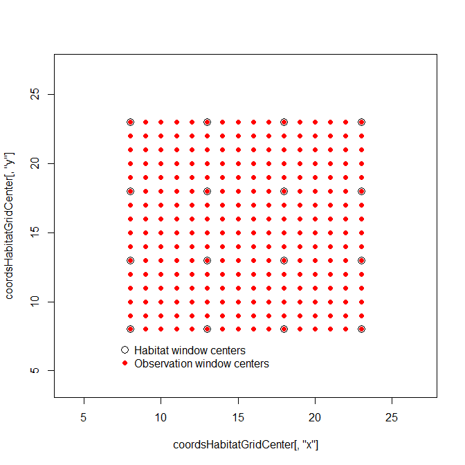

```r
## Create habitat grid
coordsHabitatGridCenter <- cbind(rep(seq(23, 8, by = -5), 4),
                                 sort(rep(seq(8, 23, by = 5), 4)))
colnames(coordsHabitatGridCenter) <- c("x","y")

## Create trap grid
coordsObsCenter <- cbind(rep(seq(8, 23, by = 1), 16),
                         sort(rep(seq(23, 8, by = -1), 16)))
colnames(coordsObsCenter) <- c("x","y")

## Plot check
plot(coordsHabitatGridCenter[,"y"] ~ coordsHabitatGridCenter[,"x"],
     xlim = c(4,27), ylim = c(4,27),
     pch = 1, cex = 1.5)
points(coordsObsCenter[,"y"] ~ coordsObsCenter[,"x"], col="red", pch=16 )
par(xpd=TRUE)
legend(x = 7, y = 7.5,
       legend=c("Habitat window centers", "Observation window centers"),
       pt.cex = c(1.5,1),
       horiz = F,
       pch=c(1,16),
       col=c("black", "red"),
       bty = 'n')
```

```r
habitatMask <- matrix(1, nrow = 4, ncol= 4, byrow = TRUE)
```

### 1.2 Rescale coordinates

To implement the local evaluation approach when fitting the SCR model (see Milleret et al. (2019) and Turek et al. (2021) for further details), we need to rescale the habitat and trapping grid coordinates so that each habitat cell is of dimension $1 \times 1$. We also need to identify the lower and upper coordinates of each habitat cell using the ‘getWindowCoords’ function.

```r
## Rescale coordinates
scaledObjects <- scaleCoordsToHabitatGrid(
  coordsData = coordsObsCenter,
  coordsHabitatGridCenter = coordsHabitatGridCenter)

## Get lower and upper cell coordinates
lowerAndUpperCoords <- getWindowCoords(
  scaledHabGridCenter = scaledObjects$coordsHabitatGridCenterScaled,
  scaledObsGridCenter = scaledObjects$coordsDataScaled,
  plot.check = F)
```

```r
trapLocal <- getLocalObjects(habitatMask = habitatMask,
                             coords = scaledObjects$coordsDataScaled,
                             dmax = 1,
                             resizeFactor = 1,
                             plot.check = F
)
```

We create the local objects to perform the local evaluation for the dead recovery locations using the ‘getLocalObjects’ function. In this model, we assume that dead recoveries can be detected anywhere in the spatial domain (including the habitat buffer). We therefore use the coordinates of the entire spatial domain (and not only the detector coordinates) to define the local objects.

```r
deadObsLocal <- getLocalObjects(habitatMask = habitatMask,
                             coords = scaledObjects$coordsHabitatGridCenterScaled,
                             dmax = 2,
                             resizeFactor = 1,
                             plot.check = F
)
```

### 1.3 Define model code

Here, we built an OPSCR model assuming a Markovian and bivariate distribution of the movement of individual activity centers across occasions. We use a multi-state sub-model for the observation process, where each individual life history is represented by a succession of up to four discrete states $z_{i,t}$: 1) ‘unborn’ if the individual has not been recruited in the population; 2) ‘alive’ if it is alive; 3) ‘culled’ if it was culled and recovered dead between the start of the previous and current occasion; 4) ‘dead’ if it was died but was not recovered dead. We assume that the cause of mortality for dead recoveries (transition from state 2 to 3) and other causes (transition from state 2 to 4) were a function of a spatial covariate. Full details are available in Milleret et al. 2022. Estimating spatially variable and density-dependent survival using open-population spatial capture-recapture models; Ecology

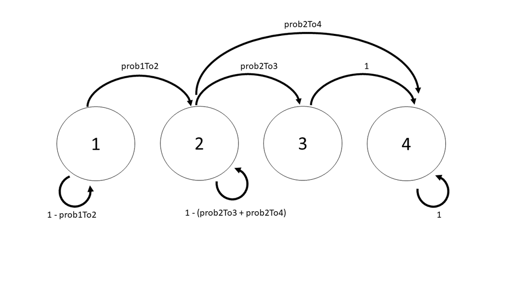

State transition

```r
modelCode <- nimbleCode({
  ##--------------------------------------------------------------------------------------------
  ##-----------------------------##
  ##------ SPATIAL PROCESS ------##
  ##-----------------------------##
  tau ~ dgamma(0.001, 0.001)
  logHabIntensity[1:numHabWindows] <- mu[1:numHabWindows]
  sumHabInt <- log(sum(mu[1:numHabWindows]))
  ## FIRST YEAR
  for(i in 1:M){
    s[i, 1:2,1] ~ dbernppAC(
      lowerCoords = lowerHabCoords[1:numHabWindows, 1:2],
      upperCoords = upperHabCoords[1:numHabWindows, 1:2],
      logIntensities = logHabIntensity[1:numHabWindows],
      logSumIntensity = sumHabInt,
      habitatGrid = habitatGrid[1:y.max,1:x.max],
      numGridRows =  y.max,
      numGridCols = x.max
    )
  }#i

  ## T>1
  for(t in 2:n.years){
    for(i in 1:M){
      s[i, 1:2, t] ~ dbernppACmovement_normal(lowerCoords = lowerHabCoords[1:numHabWindows, 1:2]
                                                , upperCoords = upperHabCoords[1:numHabWindows, 1:2]
                                                , s = s[i, 1:2, t - 1]
                                                , sd = tau
                                                , baseIntensities = mu[1:numHabWindows]
                                                , habitatGrid =  habitatGrid[1:y.max,1:x.max]
                                                , numGridRows = y.max
                                                , numGridCols = x.max
                                                , numWindows= numHabWindows
      )
    }#i
  }#t

  ##--------------------------------------------------------------------------------------------
  ##-------------------------------##
  ##----- DEMOGRAPHIC PROCESS -----##
  ##-------------------------------##
  ## INTERCEPT MORTALITY HAZARD RATES
  mhH ~ dunif(-10, 10)
  mhW ~ dunif(-10, 10)

  ## CAUSE SPECIFIC SLOPE MORTALITY
  betaH ~ dunif(-10,10)
  betaW ~ dunif(-10,10)

  ## FIRST YEAR INCLUSION PARAMETER
  gamma1 ~ dunif(0,1)
  omeg1[1:2] <- c(1-gamma1, gamma1)

  ## TIME SPECIFIC INCLUSION PARAMETER
  for(t in 1:n.years1){
    gamma[t] ~ dunif(0,1)
  }#t

  ## SPATIAL SURVIVAL
  ## SURVIVAL (CAUSE-SPECIFIC MORTALITY SPATIALLY EXPLICIT)
  mhH1[1:numHabWindows] <- exp(mhH + betaH * habCov[1:numHabWindows])
  mhW1[1:numHabWindows] <- exp(mhW + betaW * habCov[1:numHabWindows])

  ## DERIVE MORTALITY AND SURVIVAL PROBABILITIES
  phi[1:numHabWindows] <- exp(-(mhH1[1:numHabWindows] + mhW1[1:numHabWindows]))
  h[1:numHabWindows] <-  (1 - phi[1:numHabWindows]) * (mhH1[1:numHabWindows]/(mhH1[1:numHabWindows] +
                         mhW1[1:numHabWindows]))
  w[1:numHabWindows] <-  (1 - phi[1:numHabWindows]) * (mhW1[1:numHabWindows]/(mhH1[1:numHabWindows] +
                         mhW1[1:numHabWindows]))

  ## STATE TRANSITION
  for(i in 1:M){
    z[i,1] ~ dcat(omeg1[1:2])
    for(t in 1:n.years1){
      z[i,t+1] ~ dcatState1Alive2Dead( z = z[i,t]
                                     , prob1To2 = gamma[t]
                                     , prob2To3Hab = h[1:numHabWindows]
                                     , prob2To4Hab = w[1:numHabWindows]
                                     , s = s[i,1:2,t]
                                     , habitatGrid = habitatGrid[1:y.max,1:x.max])
    }#i
  }#t

  ##---------------------------------------------------------------------------------------------
  ##-----------------------------##
  ##----- DETECTION PROCESS -----##
  ##-----------------------------##
  sigma ~ dunif(0,15)
  p0 ~ dunif(0,1)

  for(t in 1:n.years){
    for (i in 1:M){

      ## ALIVE DETECTIONS
       y[i, 1:lengthYCombined,t] ~ dbinomLocal_normal(size = trials[1:n.traps],
                                                 p0 = p0,
                                                 s = s[i,1:2,t],
                                                 sigma = sigma,
                                                 trapCoords = trapCoords[1:n.traps,1:2],
                                                 localTrapsIndices = trapIndex[1:n.cells,1:maxNBDets],
                                                 localTrapsNum = nTraps[1:n.cells],
                                                 resizeFactor = resizeFactor,
                                                 habitatGrid = habitatIDDet[1:y.maxDet,1:x.maxDet],
                                                 indicator = isAlive[i,t],
                                                 lengthYCombined = lengthYCombined)


      ## DEAD RECOVERY
      y.dead[i, 1:3,t] ~ dbernppLocalDetection_normal(
                    lowerCoords= lowerHabCoords[1:numHabWindows,1:2]
                  , upperCoords= upperHabCoords[1:numHabWindows,1:2]
                  , s = s[i,1:2,t]
                  , sd = sigma
                  , baseIntensities = detReco[1:numHabWindows]
                  , habitatGridLocal=habitatGridLocal[1:y.max,1:x.max]
                  , resizeFactor=resizeFactor
                  , localObsWindowIndices = localObsWindowIndices[1:numHabWindows,1:maxNBDetsReco]
                  , numLocalObsWindows = numLocalObsWindows[1:numHabWindows]
                  , numWindows = numHabWindows
                  , indicator = z[i,t]==3
      )
    }#i
  }#t

  ##---------------------------------------------------------------------------------------------
  ##----------------------------------------##
  ##---------- DERIVED PARAMETERS ----------##
  ##----------------------------------------##
  for(i in 1:M){
    isAlive[i,1] <- (z[i,1] == 2)
    for(t in 1:n.years1){
      isAlive[i,t+1] <- (z[i,t+1] == 2)
    }
  }
  for(t in 1:n.years){
    N[t] <- sum(isAlive[1:M,t])
  }#t
})
```